# Analysis on job vacancies in Singapore

Tay Jiakang, Mila

1/2022

## R Markdown Report

This is a sample report on the trends of unemployment in Singapore. We will try to determine the current employment siutation in Singapore based on data obtained from the government database

## Describing the data set

For the report, the two data sets are the report on job vacancies in three sectors in Singapore and the ratio of vacancies to unemployment. The data contains job vacancies From the dataset, we have a total of 381 values. The headers are quarter, occupation, job_vacancy.

## Overview of data

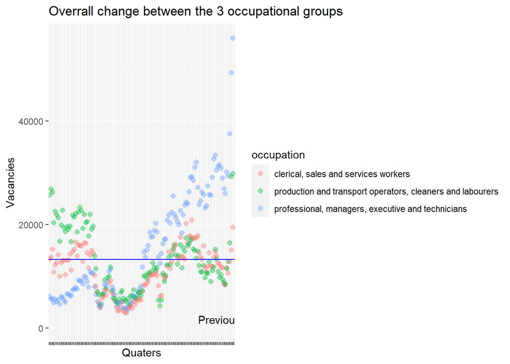

We notice that at the end of the graph, we have a large uptick, we will seek to find out more on the reason behind it. I will be focusing more on the professional workers since that has the greatest variation from visual observation.